# Презентация по лабораторной работе №5

Эмуляция и измерение потерь пакетов в глобальных сетях

Лушин А.А.

Российский университет дружбы народов, Москва, Россия

Факультет Физико-математических и естественных наук

18 февраля 2005

# Информация

## Докладчик

- Лушин Артём Андреевич
- Бакалавр направления компьютерные и информационные науки
- Кафедра теории вероятности и кибербезопасности
- Российский университет дружбы народов
- lusin5745@gmail.com

# Вводная часть

## Цели и задачи

Основной целью работы является получение навыков проведения интерактивных экспериментов в среде Mininet по исследованию параметров сети, связанных с потерей, дублированием, изменением порядка и поврежденияем пакетов при передачи данных. Эти параметры влияют на производительность протоколов и сетей.

# Ход работы

## Интерактивные исследования

Изначально мы проверили пингование между хостами без добавления потери пакетов. Потери пакетов составили 0%. Затем на одном из хостов добавили 10% потери пакетов. Общая потеря пакетов составила 9%. На втором хосте также добавили потери пакетов 10% и общая потеря пакетов увеличилась. Добавили потери пакетов в 50% и практически каждый второй пакет терялся. Также добавили процент повреждения пакетов. И добавили двойное правило, согласно которому 25% пакетов с корреляцией 50% будут отправляться мгновенно, а остальные 75% пакетов с задержкой. Добавили дублирование пакетов.

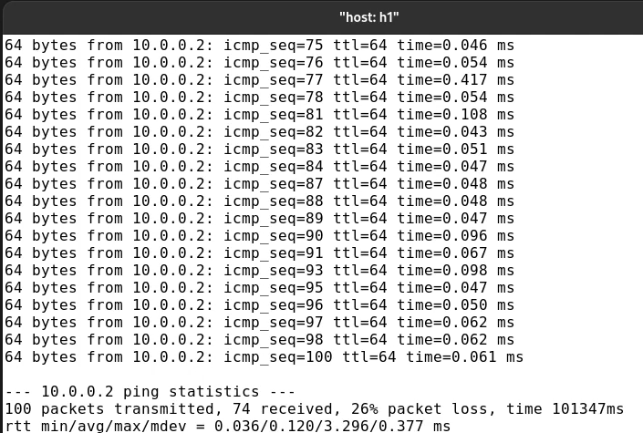

## Воспроизведение экспериментов

Создали скрипт, который будет изменять наши пакеты относительно наших поправок. Воспроизвели все эксперименты через скрипт, то есть изначально добавили 10% потери пакетов, затем добавили 50% потери, затем указали повреждённые пакеты и добавили двойное правило. В самом конце провели эксперимент с дублированием пакетов. Данные экспериментов практически совпадали с изначальными данными.

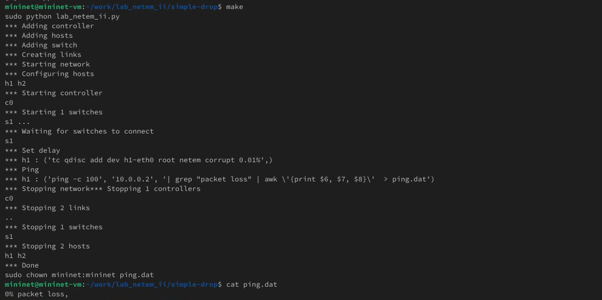

# Результаты

## Вывод

Я получил навыки проведения интерактивных экспериментов по исследованию параметров сети, связанных с потерей, дублированием, изменением порядка и повреждениями пакетов при передачи данных. Эти параметры влияют на производительность протоколов и сети.